# Makeup Shades Variability, Price, and Availability Around the World

SDS 220 Final Project

Katelyn Diaz

Smith College

Sara Gutierrez

Smith College

Allison Wong

Smith College

May 12, 2021

```r
knitr::opts_chunk$set(
  message = FALSE,
  echo = TRUE
)
library(tidyverse)
library(openintro)
library(plotly)
library(moderndive)
library(kableExtra)
library(broom)
makeupdata <- read.csv("makeupshades4 copy.csv")
                       # FinalProjectPersonalExploration/makeupshades1 copy.csv")
  #"SDS220_MakeupShadesStats/MakeupShades3 copy.csv"") <- if i need to run the data
```

```r
makeup_shades <- makeupdata %>%
  filter(!is.na(best_seller))
```

### Introduction and Explanatory Data Analysis

Throughout recent past years, the popularity of the makeup industry has skyrocketed. This most likely occurred with the rise of social media and social media personalities from YouTube, Instagram, and even TikTok. While this might seem great, one side that is often ignored is the exclusivity that comes with the makeup industry. In fact, many people with darker complexions have an extremely difficult time finding their perfect foundation shade, and this is a huge disservice to communities of color.

We took this into consideration and explored the makeup_shades dataset “from `Data.World` and their article [Diversity of Makeup Shades](https://data.world/the-pudding/diversity-of-makeup-shades). The sampled populations were best seller beauty brands in four different countries - U.S., Nigeria, India, and Japan. After consultating different lists produced from sources such as [Amazon](https://www.amazon.com/Best-Sellers-Beauty-Foundation-Makeup/zgbs/beauty/11058871), [Popsugar Beauty](https://www.popsugar.com/beauty/Bestselling-Foundations-Sephora-2017-43250396), [Refinery29](https://www.refinery29.com/en-us/skin-care-brands-women-of-color), [Beauty In Lagos](https://www.beautyinlagos.com/2017/02/nigerian-makeup-brands-you-should-know-about.html/), and [other sources](https://data.world/the-pudding/diversity-of-makeup-shades), a list of brands were compiled. To find the shade color, each brand’s website was visited in May of 2018, with the color and `price` being recorded based on the liquid foundation line that had the largest variety of shades. Adobe Photoshop was used to determine the `lightness` value.

When glimpsing the data, we noticed about ~100 `na`’s under `best_seller`. To make our analysis easier, we filtered out `na`’s from the data set. We were curious to see if there could be any relationship between the specific `lightness` and `price` (i.e. are darker shades more expensive?) as well as if this differs by country, because we believe that price is an important factor in determining the likelihood of someone purchasing a product.

The question we wanted to answer was: “Is there a relationship between price and lightness across different value makeup brands around the world?” We chose the variables `price` (quantitative response variable) and `lightness`(explanatory variable), organized by the categorical variable `best_seller` because it allowed us to see shade variability separated into four countries. This allowed us to observe the diversity of each country’s products and shades, as well as if there is any correlation with `price` in US dollars.

### Basic Data Analysis

#### `Price` Histogram

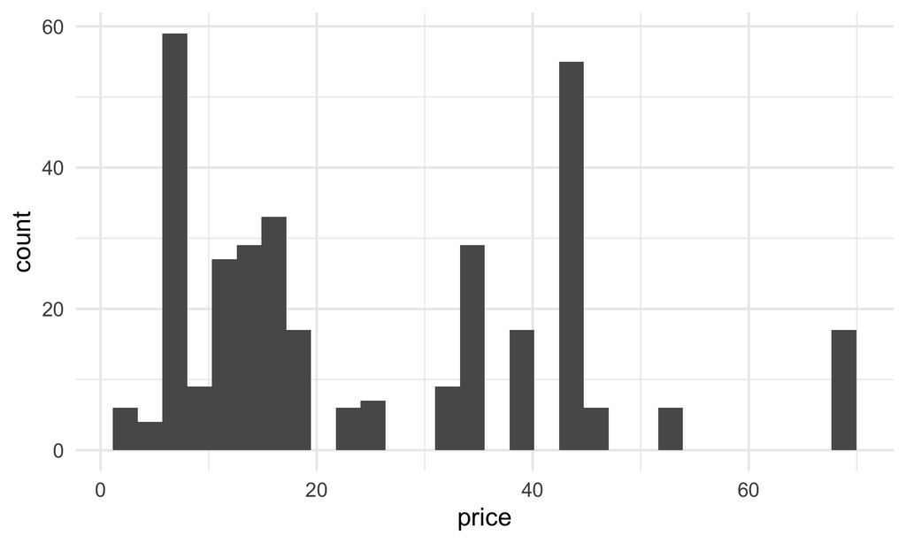

**Figure 1** Histogram for the price (in US dollars) variable

```r
ggplot(data = makeup_shades, aes(x = price)) +
  geom_histogram()+
   theme_minimal(base_size=20)
```

```r
makeup_shades %>%
  select(price) %>%
  range()
```

```
## [1]  1.49 68.00
```

> Data is right-skewed. The range of price is from $1.49 to $68.

#### `Lightness` Histogram

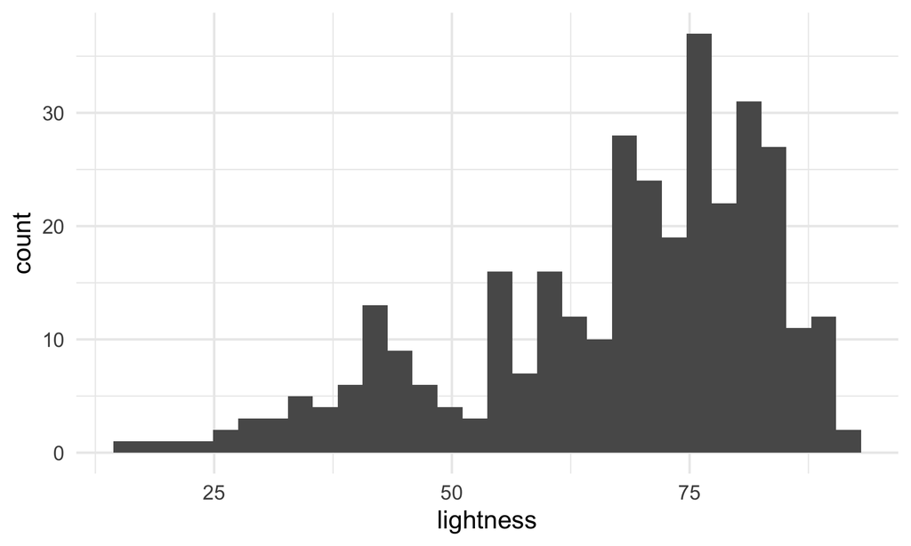

**Figure 2** Histogram for the lightness (0 - 100) variable

```r
ggplot(data = makeup_shades, aes(x = lightness)) +
  geom_histogram()+
   theme_minimal(base_size=20)
```

```r
makeup_shades %>%
  select(lightness) %>%
  range()
```

```
## [1] 16 92
```

> Data is left-skewed. The range of lightness is from 16 to 92, graded on a scale 0-100 (from darkest to lightest).

#### `Best_seller` Barplot

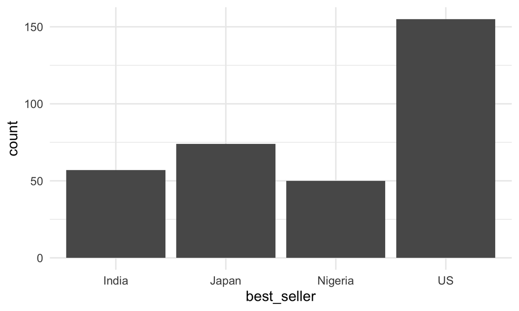

**Figure 3** Barplot of the best_seller variable

```r
ggplot(data= makeup_shades, aes(x=best_seller))+
  geom_bar()+
   theme_minimal(base_size=20)
```

```r
makeup_shades %>%
  group_by(best_seller) %>%
  select(brand)%>%
  count()
```

| best_seller | n |
| --- | --- |
| India | 57 |
| Japan | 74 |
| Nigeria | 50 |
| US | 155 |

#### Scatterplot of Variables

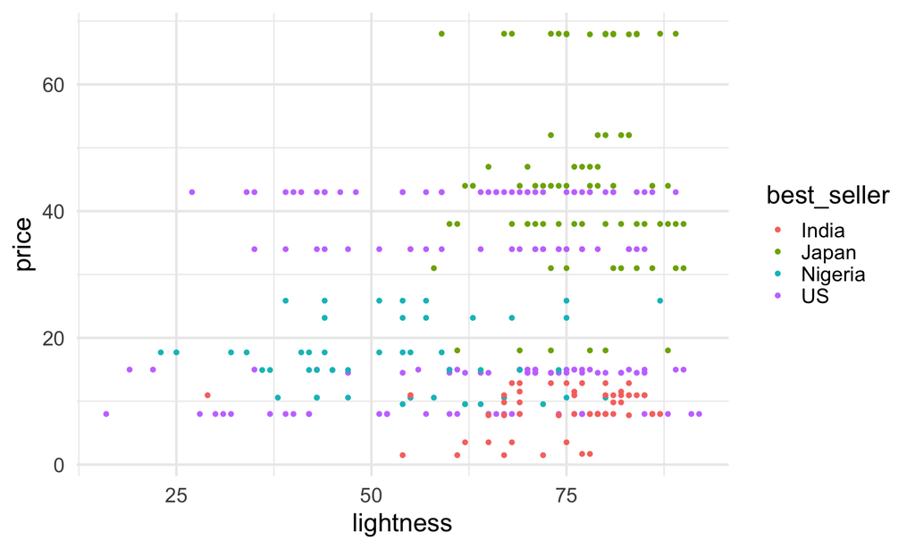

**Figure 4** Scatterplot of Lightness and Price (numerical variables), colored by Best Seller (categorical variable)

```r
ggplot(data = makeup_shades, aes(x = lightness, y=price, col = best_seller)) +
  geom_point()+
   theme_minimal(base_size=20)
```

> A great majority of the data points are concentrated towards the right of the scatterplot, giving evidence of more products with lighter shades available on the market.

### Linear Regressions

#### Hypothesis Test

For our linear regression models, we explored whether or not there was a difference in price of makeup `best_seller`’s across different countries. Our **null hypothesis** is that there is *no difference* in price, while our **alternative hypothesis** is that there *is* a difference in price.

#### Parallel Slopes Model and Analysis

```r
makeup_model <- lm(price ~ lightness + best_seller, data = makeupdata)
summary(makeup_model)  %>%
  tidy() %>%
  kbl() %>%
  kable_material(c("striped", "hover"))
```

| term | estimate | std.error | statistic | p.value |
| --- | --- | --- | --- | --- |
| (Intercept) | 9.1646864 | 3.9233841 | 2.3359136 | 0.0200924 |
| lightness | -0.0073262 | 0.0480414 | -0.1524975 | 0.8788875 |
| best_sellerJapan | 36.7258903 | 2.1806491 | 16.8417237 | 0.0000000 |
| best_sellerNigeria | 7.8755997 | 2.5958480 | 3.0339218 | 0.0026050 |
| best_sellerUS | 15.5684387 | 1.9672461 | 7.9138236 | 0.0000000 |

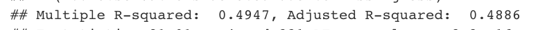

```r
knitr::include_graphics("ParallelSlopes.png")
```

> Through this summary model, we are able to better observe our data in the parallel slopes plot. We extraplolated essential information such as the intercepts and slopes of our regression lines in order to better interpret any trends in our data. We also evaluated the p-values, such as the value of approximately 0.02 in row 1 for our intercept, to help us further understand whether or not this fit our dataset properly. Considering that the multiple R<sup>2</sup> value is 0.4947, the data does not closely fit our fitted regression lines.

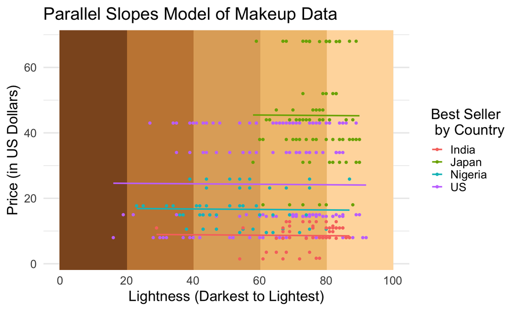

**Figure 5a** Parallel slopes model plot comparing lightness (x-axis) to price in dollars (y-axis). India is acting as the baseline (main y-intercept of comparison). Plot compares price and lightness of foundations across four different countries.

```r
ggplot(makeup_shades, aes(lightness, price, col = best_seller)) +
    geom_rect(data=NULL,
             aes(xmin=80,xmax=100,ymin=-Inf,ymax=Inf),
             fill="#ffdbac", col = "#ffdbac")+
  geom_rect(data=NULL,
            aes(xmin=60,xmax=80,ymin=-Inf,ymax=Inf),
            fill="#f1c27d", col="#f1c27d")+
  geom_rect(data=NULL,
            aes(xmin=40,xmax=60,ymin=-Inf,ymax=Inf),
            fill="#e0ac69", col="#e0ac69")+
  geom_rect(data=NULL,
            aes(xmin=20,xmax=40,ymin=-Inf,ymax=Inf),
            fill="#c68642", col="#c68642")+
  geom_rect(data=NULL,
             aes(xmin=0,xmax=20,ymin=-Inf,ymax=Inf),
             fill="#8d5524", col="#8d5524")+
  scale_x_continuous(breaks=c(0,20,40,60,80,100))+
 scale_color_manual(values=c("#001eff", #india is first
                             "#4deeea", "#ffe700", "#74ee15", "FFFFFF"))+ # color codes the data
 theme_minimal(base_size=20
               # ,
               # scale_fill_discrete(name = "Country")
            )+ # makes a white background, base size changes font size
  labs(title="Parallel Slopes Model of Makeup Data",
       # subtitle="India as the baseline. Looking for correlation between price and lightness\n of foundations across different countries.",
       y= "Price (in US Dollars)",
       x ="Lightness (Darkest to Lightest)") +
  scale_colour_discrete("Best Seller\n by Country") +
  geom_point() +
   geom_parallel_slopes(se=FALSE)
```

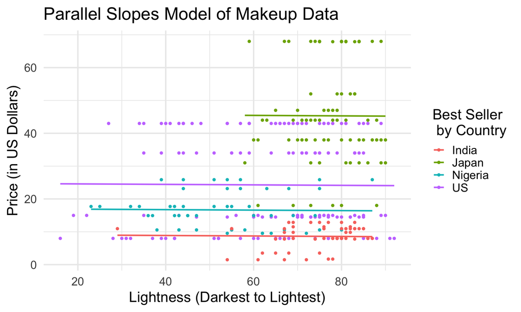

**Figure 5b** Parallel slopes model graph with white background to better view data points

```r
ggplot(makeup_shades, aes(lightness, price, col = best_seller)) +
  scale_x_continuous(breaks=c(0,20,40,60,80,100))+
  theme_minimal(base_size=20)+
  labs(title="Parallel Slopes Model of Makeup Data",
       y= "Price (in US Dollars)",
       x ="Lightness (Darkest to Lightest)") +
  scale_colour_discrete("Best Seller\n by Country") +
  geom_point() +
   geom_parallel_slopes(se=FALSE)
```

Besides from our baseline, we also investigated data for makeup bestsellers in Japan. This was represented by the equation: **price_hat_Japan = (9.2 + 36.72) -0.007326x**. As we can see, the slope stays constant for all lines, so we can expect to see that for every unit increase in lightness, there is also a *decrease* in price by approximately $0.007 on average. When the lightness is equal to zero, we expect to see the price to be, on average, $(9.2 + 36.72), or **$45.92**, so in spite of this constant slope, Japan starts off at a much higher price. This leads us to believe that from the start, the cost of makeup best sellers in Japan is much more expensive than the cost in India.

Nigeria, on the other hand, does not appear to show behavior as drastic as Japan. The regression line for Nigeria is represented by **price_hat_Nigeria = (9.2 + 7.88) -0.007326x**, where for every one unit increase in lightness, we expect the price to decrease by $0.007 on average. We also expect the price to be (9.2 + 7.88), or **$17.08** on average, when the lightness is equal to zero. While this price might not be as expensive as the price in Japan, it is still higher than India because we add $7.88 to India’s intercept ($9.20).

Lastly, we analyzed at the data for makeup bestsellers in the U.S. The regression line for the U.S. is represented by the equation **price_hat_US = (9.2 + 15.57) -0.007326x**. We expect the price to decrease, on average, by $0.007 for every one unit increase in lightness, and when the lightness is equal to zero, the price is expected to be $(9.2 + 15.57) or **$24.77** on average. Compared to India, we expect for the price of makeup best sellers in the U.S. to be $15.57 more expensive.

From this model, when the lightness is equal to zero, we can see that the price of makeup best sellers in India is the cheapest at $9.20, compared to the other countries which have much higher prices. Japan being the most expensive at $45.92, then the U.S. at $24.77, and finally Nigeria at $17.08. We can see that there is a negative correlation between price and lightness in all countries (India, Japan, Nigeria, the U.S.) as a result of having a negative slope.

#### Interaction Model and Analysis

```r
makeup_model2 <- lm(price ~ lightness * best_seller, data = makeup_shades)
summarymm <- summary(makeup_model2)%>%
  tidy() %>%
  kbl() %>%
  kable_material(c("striped", "hover"))
summarymm
```

| term | estimate | std.error | statistic | p.value |
| --- | --- | --- | --- | --- |
| (Intercept) | 4.1129345 | 12.2155248 | 0.3366973 | 0.7365604 |
| lightness | 0.0607310 | 0.1630732 | 0.3724155 | 0.7098240 |
| best_sellerJapan | 36.5520115 | 18.4149694 | 1.9849075 | 0.0479875 |
| best_sellerNigeria | 12.6389737 | 13.9894499 | 0.9034647 | 0.3669424 |
| best_sellerUS | 21.7276806 | 12.8213862 | 1.6946437 | 0.0910922 |
| lightness:best_sellerJapan | -0.0001561 | 0.2414611 | -0.0006464 | 0.9994846 |
| lightness:best_sellerNigeria | -0.0626467 | 0.2046300 | -0.3061462 | 0.7596876 |
| lightness:best_sellerUS | -0.0851736 | 0.1731450 | -0.4919208 | 0.6231044 |

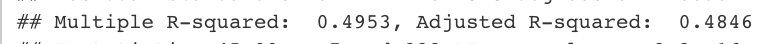

```r
knitr::include_graphics("InteractionModel.png")
```

> This summary model describes what is observed in our interaction model plot. We paid close attention to the p-values, which helped us determine that this is not an ideal plot. For example, the p-values of approximately 0.7 in rows 1 and 2 and 0.9 in row 6 which are above the significance level of 0.05 led us to being unable to reject the null hypothesis. Considering that the multiple R<sup>2</sup> value is 0.4953, the regression lines do not fit the data properly. Looking back, the parallel slopes model had a similar R<sup>2</sup> value at 0.4947. Although the interaction model’s regression lines do fit the data more closely, we did not think that a 0.0006 difference in R<sup>2</sup> values constitutes using the more advanced model.

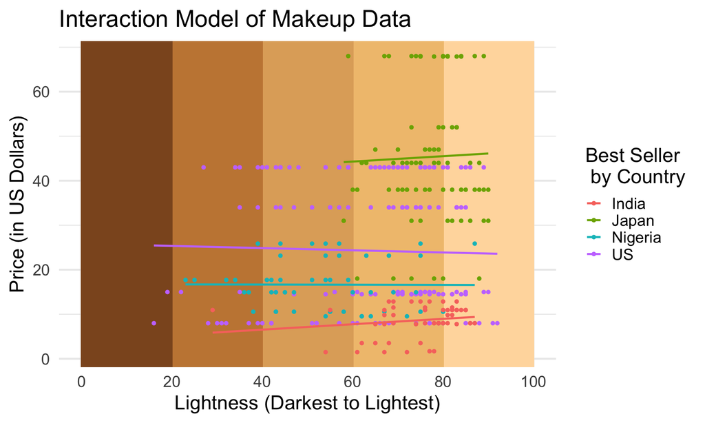

**Figure 6** Interaction model linearity plot comparing lightness (x-axis) to price in dollars (y-axis). India is acting as the baseline (main slope of comparison). Plot compares price and lightness of foundations across four different countries. We did not choose this model.

```r
ggplot(makeup_shades, aes(lightness, price, col = best_seller))+

  geom_rect(data=NULL,
             aes(xmin=80,xmax=100,ymin=-Inf,ymax=Inf),
             fill="#ffdbac", col = "#ffdbac")+
  geom_rect(data=NULL,
            aes(xmin=60,xmax=80,ymin=-Inf,ymax=Inf),
            fill="#f1c27d", col="#f1c27d")+
  geom_rect(data=NULL,
            aes(xmin=40,xmax=60,ymin=-Inf,ymax=Inf),
            fill="#e0ac69", col="#e0ac69")+
  geom_rect(data=NULL,
            aes(xmin=20,xmax=40,ymin=-Inf,ymax=Inf),
            fill="#c68642", col="#c68642")+
  geom_rect(data=NULL,
             aes(xmin=0,xmax=20,ymin=-Inf,ymax=Inf),
             fill="#8d5524", col="#8d5524")+
  geom_point() +
  scale_x_continuous(breaks=c(0,20,40,60,80,100))+
  geom_smooth(method = "lm", se=FALSE) +## lm means line, se = FALSE gets rid of the buffer
 scale_color_manual(values=c("#001eff", #india is first
                             "#4deeea", "#ffe700", "#74ee15", "FFFFFF"))+ # color codes the data
 theme_minimal(base_size=20
               # ,
               # scale_fill_discrete(name = "Country")
            )+ # makes a white background, base size changes font size
  labs(title="Interaction Model of Makeup Data",
       # subtitle="India as the baseline. Looking for correlation between price and lightness\n of foundations across different countries.",
       y= "Price (in US Dollars)",
       x ="Lightness (Darkest to Lightest)") +
  scale_colour_discrete("Best Seller\n by Country")
```

At first glance, our interaction model may look similar to our parallel slopes model, but they are actually different. See Appendix for further explanation.

### Limitations Plots

#### Constant Variance Plot

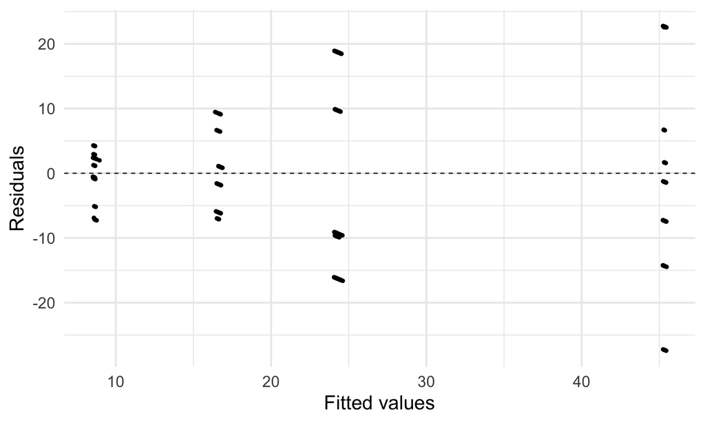

**Figure 7a** Residuals versus fitted values plot. Dotted line represents where residuals are equal 0.

```r
ggplot(data = makeup_model, aes(x = .fitted, y = .resid)) +
  geom_point() +
  geom_hline(yintercept = 0, linetype = "dashed") +
   theme_minimal(base_size=20)+
  xlab("Fitted values") +
  ylab("Residuals")
```

Our constant variance plot is not ideal. The fitted values represent the price we expect to see from our linear model using the makeup’s lightness while the residuals represent the observed price minus the expected price. Each point is the expected price from our model and how close it was to the original price in the data. An ideal plot would have residual values within a certain range throughout all fitted values. We would be able to draw a rectangle encompassing all the points to show that across all levels of our expected prices, our residuals stay within a certain range and has constant variance. Ideally, the plot would demonstrate as our expected prices from our model increase, we would expect similar differences in our residuals.

However, from our plot, it is clear that a box would not we suit the points. The points instead fit a more triangular shape with a smaller range of residual values (from -7 to 5) at smaller fitted values around an expected price of 10 and gradually expand to the largest range (-27 to 23) at larger fitted values around an expected price of 45. Thus, our constant variance plot demonstrates that as our expected prices from our model increase, we also expect greater differences in our residuals. Our model does not demonstrate constant variance.

#### Residuals Plot

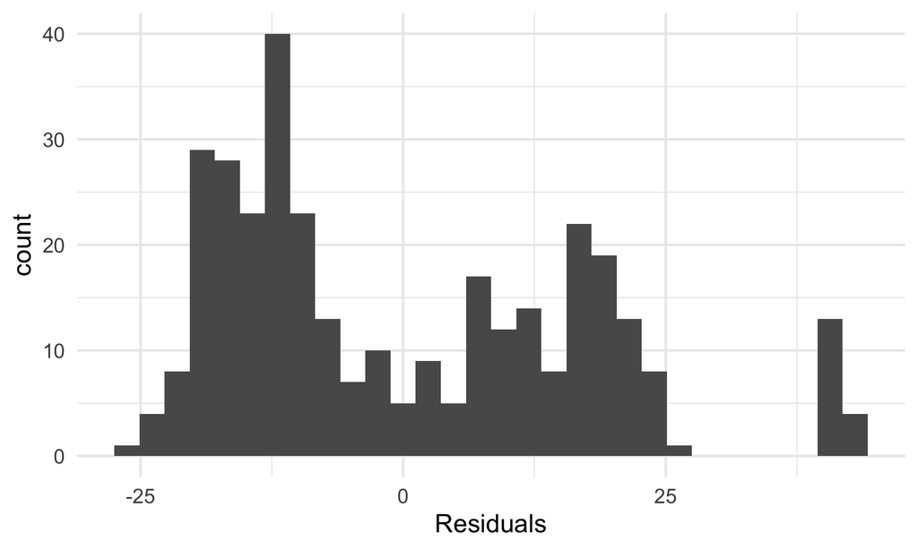

**Figure 7b** Histogram of the residuals

```r
plot1a <- ggplot(makeup_shades, aes(x = lightness, y = price))+
  geom_point()+
  geom_point(aes(color=best_seller))+
  geom_smooth(method = "lm", se = FALSE) # drawing the regression line
#plot1a
#ggplotly(plot1a)
# Summary statistics
question1a <- lm(price ~ lightness, data = makeup_shades)

ggplot(data = question1a, aes(x = .resid)) +
  geom_histogram() +
  xlab("Residuals")+
   theme_minimal(base_size=20)
```

#### Quantile-quantile plot

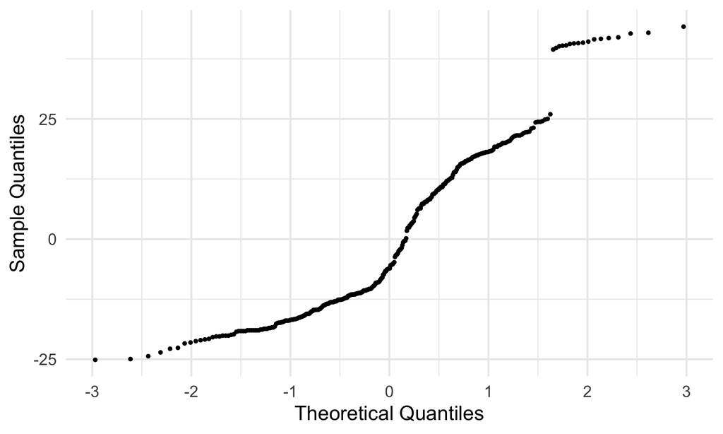

**Figure 7c** Qq-plot of the residuals

```r
qqplot <- lm(price ~ lightness, data = makeup_shades)
ggplot(data = question1a, aes(sample = .resid)) +
  geom_qq() +
  xlab("Theoretical Quantiles") + # curves line up with the two peaks in the histogram
  ylab("Sample Quantiles") +
   theme_minimal(base_size=20)
```

### Limitations and Conclusion

The question we set out to answer was whether there is a relationship between price and lightness across different value makeup brands around the world. We found no evidence that lightness is associated with price. Although this was not the original question we sought to answer, there is evidence that different countries have different prices in U.S. dollars for makeup because the p values on our model’s summary table for each individual countries’ intercept was much less than the statistical significant value 0.05. If we wanted to continue with this research, we may want to look at the data for makeup prices in more countries to see if makeup prices differ based on shade in different countries. This would give us a broader view to see how price is based on makeup shades throughout more of the world.

Our model did not fit well to the assumption metrics used to determine whether or model accurately represents the data. For linearity, each line in our parallel slopes model losely fits the points because many of the points followed alongside the line, but was either had prices extremely higher than the price for the line or lower than that price. Additionally, our model did not have nearly normal residuals or demonstrate constant variance. Thus, we cannot trust our p-values or the area under the curve for our assumed normal distribution. However, we created our model using these p-values, which is a serious limitation of our model. Finally, to create our model, we also had to assume that makeup prices from brands around the world were independent of each other.

Also, there were many limitations in this data set. The data set included many brands that have `na` for `best_seller` value , and we filtered all of those brands out of our data. Because we filtered out these brands, it may not be appropriate to generalize these results to all brands or even all countries because there were only 4 countries that were best sellers in the data set. Makeup prices may not vary greatly as lightness increases in a country in our data set, but in another country not represented by our data, it still could vary greatly. Similarly, a makeup brand in our data may not accurately show how prices for different shades of lightness vary in a different brand.

For future iterations, we would like to work with a data set that includes more liquid foundation lines for each brand instead of only including the makeup line with the most number of shades available. With this information, we could see how many shades brands make available on average and even throughout the world. It would also be helpful to use data from multiple years, not just 2018, to see how the number of makeup shades available changes year to year. Finally, it would be interesting to use other variables in this dataset, such as `group`. This variable not only includes best sellers for all four countries in the dataset, but it also separates products as BIPOC-recommended Brands with BIPOC Founders and BIPOC-recommended Brands with White Founders. Every product can only be placed in one group, and it would be fascinating to see differences in the products placed in each group relating to their price and lightness.

…

### Appendix

*Further explanations for the Interaction Model:*

Besides from our baseline, we also looked at data for makeup bestsellers in Japan. This was represented by the equation: **price_hat_Japan = (4.11 + 36.55) + (0.0607310 - 0.0001561)x**. On average, we can expect to see that for every unit increase in lightness, there is an increase in price by $(0.0607310 - 0.0001561), or approximately $0.06. When the lightness is equal to zero, we expect to see the price to be, on average, $(4.11 + 36.55), or $40.66. Even though the slope of the baseline and the slope of **price_hat_Japan** are very similar, Japan is already at a much higher price.

Nigeria on the other hand does not appear to show behavior as extreme as Japan. The regression line for Nigeria is represented by **price_hat_Nigeria = (4.11 + 12.64) + (0.0607310 - 0.0626467)x**, where for every one unit increase in lightness, we expect the price to *decrease* by $(0.0607310 - 0.0626467), or $0.0019 on average. The slope of **price_hat_Nigeria** is roughly the same as the baseline, since that value isn’t even equal to one cent. When the lightness is equal to zero, we expect the price to be (4.11 + 12.64), or $16.75 on average. While this price might not be as expensive as the price in Japan, it is still higher than the baseline.

In general, we can see that the price of makeup best sellers in India is the cheapest at $4.11, compared to the other countries which have much higher prices. Japan being the most expensive at $40.66, then the U.S. at $25.84, and finally Nigeria at $16.75. From the slopes, we can see that in Japan and India, there is a positive correlation between price and lightness, and then in Nigeria and the U.S., a negative correlation between the two.

### References

Lee, Jason. 2018. “Data.world Diversity of Makeup Shades.” Data.World. https://data.world/the-pudding/diversity-of-makeup-shades.

Penrose, Nerisha. 2018. “It’s 2018. Why Is It Still A Struggle To Find Foundation For Dark Skin?” Elle. https://www.elle.com/beauty/makeup-skin-care/a22687914/struggle-to-find-dark-skin-foundation-woc-influencers-beauty-blender-tarte/.